# Tugas Kuliah 2

Naufal Azizan Rafiansyah

2025-09-04

# Library

```r
library(dplyr)
library(TTR)
library(forecast)
library(lmtest)
library(orcutt)
library(HoRM)
library(readxl)
```

# Import Data

```r
df <- read_excel("C://Users//NAUFAL AZIZAN R//Downloads//DataIPM.xlsx")
df
```

```
## # A tibble: 15 × 2
##    Tahun   IPM
##    <dbl> <dbl>
##  1  2010  65.2
##  2  2011  65.9
##  3  2012  66.7
##  4  2013  67.2
##  5  2014  67.6
##  6  2015  68.4
##  7  2016  69.0
##  8  2017  69.6
##  9  2018  70.2
## 10  2019  70.7
## 11  2020  70.9
## 12  2021  71.3
## 13  2022  71.8
## 14  2023  72.5
## 15  2024  73.0
```

# Eksplorasi Data

```r
#Membentuk objek time series
data.ts<-ts(df$IPM)
data.ts
```

```
## Time Series:
## Start = 1
## End = 15
## Frequency = 1
##  [1] 65.20 65.89 66.68 67.17 67.63 68.38 69.05 69.65 70.17 70.72 70.91 71.28
## [13] 71.84 72.50 73.03
```

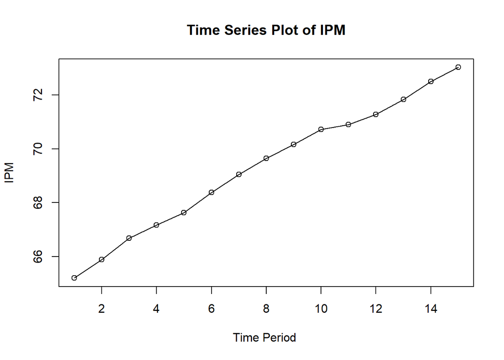

```r
#Membuat plot time series
ts.plot(data.ts, xlab="Time Period ", ylab="IPM", main= "Time Series Plot of IPM")
points(data.ts)
```

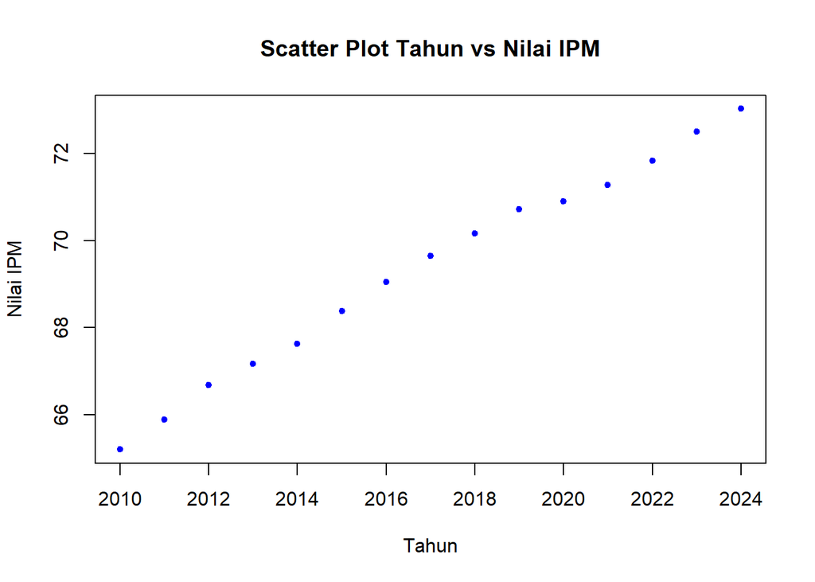

```r
#Eksplorasi Data
#Pembuatan Scatter Plot
plot(df$Tahun,df$IPM, pch = 20, col = "blue",
     main = "Scatter Plot Tahun vs Nilai IPM",
     xlab = "Tahun",
     ylab = "Nilai IPM")
```

```r
#Menampilkan Nilai Korelasi
cor(df$Tahun,df$IPM)
```

```
## [1] 0.9962139
```

Berdasarkan scatter plot dan nilai korelasi, terlihat bahwa terdapat hubungan positif yang cukup kuat antara Tahun dan Nilai IPM. Hal ini menunjukkan bahwa seiring berjalannya waktu, nilai IPM cenderung meningkat.

# Model Regresi dan Deteksi Autokorelasi

```r
#Pembuatan Model Regresi
#model regresi
model<- lm(IPM~Tahun, data = df)
summary(model)
```

```
##
## Call:
## lm(formula = IPM ~ Tahun, data = df)
##
## Residuals:
##      Min       1Q   Median       3Q      Max
## -0.33125 -0.15205 -0.06232  0.19116  0.31000
##
## Coefficients:
##               Estimate Std. Error t value Pr(>|t|)
## (Intercept) -1.028e+03  2.656e+01  -38.71 8.19e-15 ***
## Tahun        5.441e-01  1.317e-02   41.32 3.53e-15 ***
## ---
## Signif. codes:  0 '***' 0.001 '**' 0.01 '*' 0.05 '.' 0.1 ' ' 1
##
## Residual standard error: 0.2204 on 13 degrees of freedom
## Multiple R-squared:  0.9924, Adjusted R-squared:  0.9919
## F-statistic:  1707 on 1 and 13 DF,  p-value: 3.529e-15
```

Model yang dihasilkan adalah
$$y_i=-1028+0.5441x_t$$
Berdasarkan ringkasan model dapat diketahui bahwa hasil uji F memiliki *p-value* < $\alpha$ (5%). Artinya, minimal terdapat satu variabel yang berpengaruh nyata terhadap model. Hasil uji-t parsial kedua parameter regresi, yaitu intersep dan koefisien regresi juga menunjukkan hal yang sama, yaitu memiliki *p-value* < $\alpha$ (5%) sehingga nyata dalam taraf 5%. Selanjutnya dapat dilihat juga nilai $R^2=0.9924$. Artinya, sebesar 99.24% keragaman nilai IPM dapat dijelaskan oleh peubah Tahun. Hasil ini menunjukkan hasil yang bagus, seolah mendapatkan hasil terbaik. Namun, kita perlu melakukan uji terhadap sisaannya seperti berikut ini.

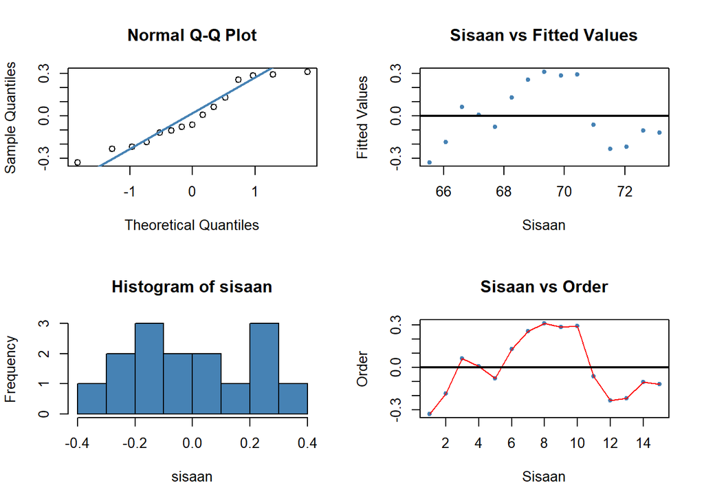

```r
#sisaan dan fitted value
sisaan<- residuals(model)
fitValue<- predict(model)

#Diagnostik dengan eksploratif
par(mfrow = c(2,2))
qqnorm(sisaan)
qqline(sisaan, col = "steelblue", lwd = 2)
plot(fitValue, sisaan, col = "steelblue", pch = 20, xlab = "Sisaan", ylab = "Fitted Values", main = "Sisaan vs Fitted Values")
abline(a = 0, b = 0, lwd = 2)
hist(sisaan, col = "steelblue")
plot(seq(1,15,1), sisaan, col = "steelblue", pch = 20, xlab = "Sisaan", ylab = "Order", main = "Sisaan vs Order")
lines(seq(1,15,1), sisaan, col = "red")
abline(a = 0, b = 0, lwd = 2)
```

```r
#Melihat Sisaan Menyebar Normal/Tidak
#H0: sisaan mengikuti sebaran normal
#H1: sisaan tidak mengikuti sebaran normal
shapiro.test(sisaan)
```

```
##
##  Shapiro-Wilk normality test
##
## data:  sisaan
## W = 0.92788, p-value = 0.2536
```

```r
ks.test(sisaan, "pnorm", mean=mean(sisaan), sd=sd(sisaan))
```

```
##
##  Exact one-sample Kolmogorov-Smirnov test
##
## data:  sisaan
## D = 0.15095, p-value = 0.8352
## alternative hypothesis: two-sided
```

Berdasarkan uji formal Saphiro-Wilk dan Kolmogorov-Smirnov didapatkan nilai *p-value* > $\alpha$ (5%). Artinya, cukup bukti untuk menyatakan sisaan berdistribusi normal.

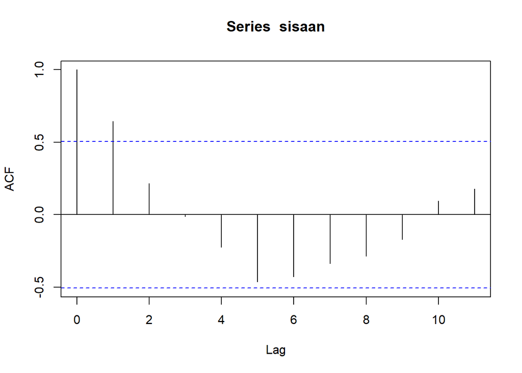

```r
acf(sisaan)
```

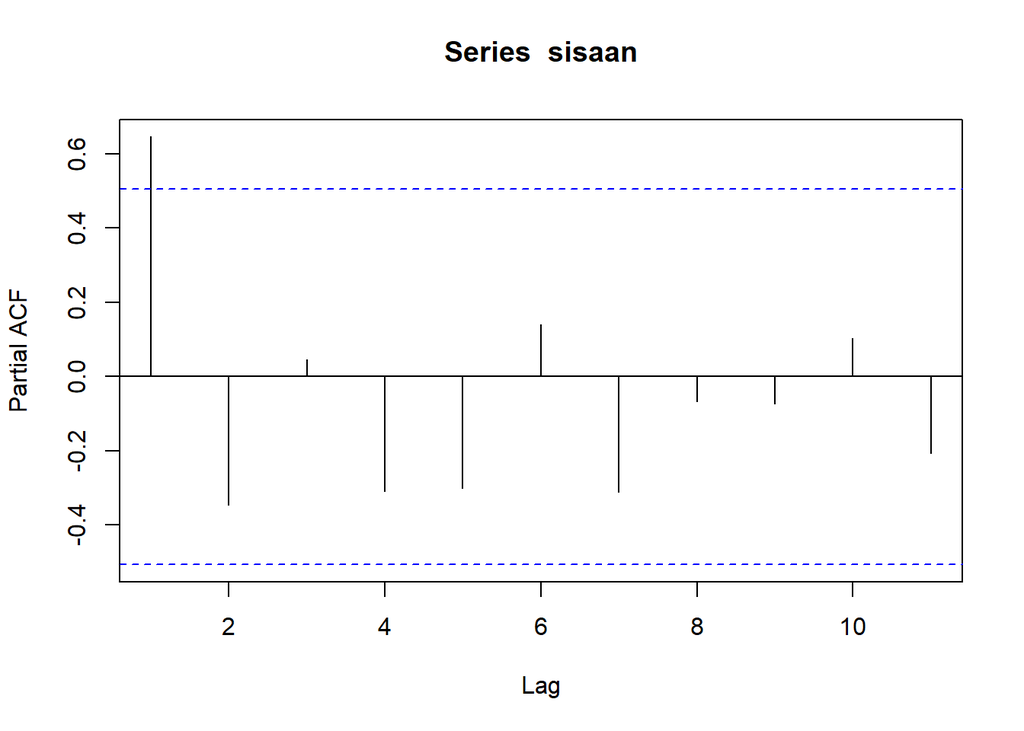

```r
pacf(sisaan)
```

Berdasarkan plot PACF di atas, terlihat bahwa ada autokorelasi pada lag 1 karena nilai PACF pada lag 1 berada di luar batas signifikan.

```r
#Deteksi autokorelasi dengan uji-Durbin Watson
#H0: tidak ada autokorelasi
#H1: ada autokorelasi
dwtest(model)
```

```
##
##  Durbin-Watson test
##
## data:  model
## DW = 0.51217, p-value = 2.265e-05
## alternative hypothesis: true autocorrelation is greater than 0
```

Berdasarkan uji Durbin-Watson didapatkan nilai *p-value* < $\alpha$ (5%). Artinya, cukup bukti untuk menyatakan ada autokorelasi pada model regresi ini.

# Penanganan Autokorelasi

## Cochrane-Orcutt

```r
#Penanganan Autokorelasi Cochrane-Orcutt
modelCO<-cochrane.orcutt(model)
modelCO
```

```
## Cochrane-orcutt estimation for first order autocorrelation
##
## Call:
## lm(formula = IPM ~ Tahun, data = df)
##
##  number of interaction: 28
##  rho 0.67673
##
## Durbin-Watson statistic
## (original):    0.51217 , p-value: 2.265e-05
## (transformed): 1.53904 , p-value: 1.067e-01
##
##  coefficients:
## (Intercept)       Tahun
## -943.294031    0.502131
```

Berdasarkan hasil keluaran model setelah dilakukan penanganan adalah sebagai berikut.
$$y_i=-943.294031+0.502131x_t$$
Hasil juga menunjukkan bahwa nilai DW dan p-value meningkat menjadi $1.53904$ dan $0.1067$. Nilai DW sudah berada pada rentang DU < DW < 4-DU atau $1.3605 < DW < 2,6395$. Hal tersebut juga didukung dengan nilai *p-value* > 0.05, artinya belum cukup bukti menyatakan bahwa sisaan terdapat autokorelasi pada taraf nyata 5%. Untuk nilai $ρ ̂$ optimum yang digunakan adalah $0.67673$

```r
#Rho optimum
rho<- modelCO$rho
rho
```

```
## [1] 0.6767299
```

```r
IPM <- df$IPM
Tahun <- df$Tahun
```

```r
IPM[-1]
```

```
##  [1] 65.89 66.68 67.17 67.63 68.38 69.05 69.65 70.17 70.72 70.91 71.28 71.84
## [13] 72.50 73.03
```

```r
#Transformasi Manual
IPM.trans<- IPM[-1]-IPM[-15]*rho
Tahun.trans<- Tahun[-1]-Tahun[-15]*rho
modelCOmanual<- lm(IPM.trans~Tahun.trans)
summary(modelCOmanual)
```

```
##
## Call:
## lm(formula = IPM.trans ~ Tahun.trans)
##
## Residuals:
##      Min       1Q   Median       3Q      Max
## -0.24378 -0.10197  0.04366  0.10117  0.12907
##
## Coefficients:
##               Estimate Std. Error t value Pr(>|t|)
## (Intercept) -304.93874   17.54340  -17.38 7.13e-10 ***
## Tahun.trans    0.50213    0.02687   18.69 3.08e-10 ***
## ---
## Signif. codes:  0 '***' 0.001 '**' 0.01 '*' 0.05 '.' 0.1 ' ' 1
##
## Residual standard error: 0.131 on 12 degrees of freedom
## Multiple R-squared:  0.9668, Adjusted R-squared:  0.964
## F-statistic: 349.2 on 1 and 12 DF,  p-value: 3.078e-10
```

```r
#Mencari Penduga Koefisien Regresi setelah Transformasi ke Persamaan Awal
b0bintang <- modelCOmanual$coefficients[-2]
b0 <- b0bintang/(1-rho)
b1 <- modelCOmanual$coefficients[-1]
b0
```

```
## (Intercept)
##    -943.294
```

```r
b1
```

```
## Tahun.trans
##    0.502131
```

# Metode Hildreth-Lu

```r
library(HoRM)

# ambil y dan x (satu prediktor saja)
y <- df$IPM
x <- df$Tahun

# grid search rho 0–0.9
r <- seq(0, 0.9, by = 0.1)
tab <- data.frame(
  rho = r,
  SSE = sapply(r, function(rr) deviance(hildreth.lu(y, x, rr)))
)

tab            # tabel rho vs SSE
```

```
##    rho       SSE
## 1  0.0 0.4865824
## 2  0.1 0.4097853
## 3  0.2 0.3452418
## 4  0.3 0.2929519
## 5  0.4 0.2529156
## 6  0.5 0.2251330
## 7  0.6 0.2096040
## 8  0.7 0.2063286
## 9  0.8 0.2153068
## 10 0.9 0.2365387
```

```r
rho_hat <- tab$rho[which.min(tab$SSE)]   # rho terbaik
fit_hl  <- hildreth.lu(y, x, rho_hat)    # model final
summary(fit_hl)
```

```
##
## Call:
## lm(formula = y ~ x)
##
## Residuals:
##      Min       1Q   Median       3Q      Max
## -0.25014 -0.10136  0.04179  0.10471  0.13071
##
## Coefficients:
##               Estimate Std. Error t value Pr(>|t|)
## (Intercept) -280.82714   17.55961  -15.99 1.86e-09 ***
## x              0.49857    0.02898   17.20 8.02e-10 ***
## ---
## Signif. codes:  0 '***' 0.001 '**' 0.01 '*' 0.05 '.' 0.1 ' ' 1
##
## Residual standard error: 0.1311 on 12 degrees of freedom
## Multiple R-squared:  0.961,  Adjusted R-squared:  0.9578
## F-statistic:   296 on 1 and 12 DF,  p-value: 8.025e-10
```

```r
#Penanganan Autokorelasi Hildreth lu
# Hildreth-Lu
hildreth.lu.func<- function(r, model){
  x <- model.matrix(model)[,-1]
  y <- model.response(model.frame(model))
  n <- length(y)
  t <- 2:n
  y <- y[t]-r*y[t-1]
  x <- x[t]-r*x[t-1]

  return(lm(y~x))
}

#Pencariab rho yang meminimumkan SSE
r <- c(seq(0.1,0.9, by= 0.1))
tab <- data.frame("rho" = r, "SSE" = sapply(r, function(i){deviance(hildreth.lu.func(i, model))}))
round(tab, 4)
```

```
##   rho    SSE
## 1 0.1 0.4098
## 2 0.2 0.3452
## 3 0.3 0.2930
## 4 0.4 0.2529
## 5 0.5 0.2251
## 6 0.6 0.2096
## 7 0.7 0.2063
## 8 0.8 0.2153
## 9 0.9 0.2365
```

Berdasarkan tabel di atas, didapatkan nilai rho yang meminimumkan SSE ada diantara 0.6-0.7. Untuk mendapatkan nilai rho yang lebih optimal, akan dilakukan pencarian nilai rho di sekitar 0.6 - 0.7 dengan interval 0.001.

```r
#Rho optimal di sekitar 0.6 - 0.7
rOpt <- seq(0.6,0.7, by= 0.001)
tabOpt <- data.frame("rho" = rOpt, "SSE" = sapply(rOpt, function(i){deviance(hildreth.lu.func(i, model))}))
head(tabOpt[order(tabOpt$SSE),])
```

```
##      rho       SSE
## 78 0.677 0.2059969
## 77 0.676 0.2059971
## 79 0.678 0.2059978
## 76 0.675 0.2059986
## 80 0.679 0.2060000
## 75 0.674 0.2060014
```

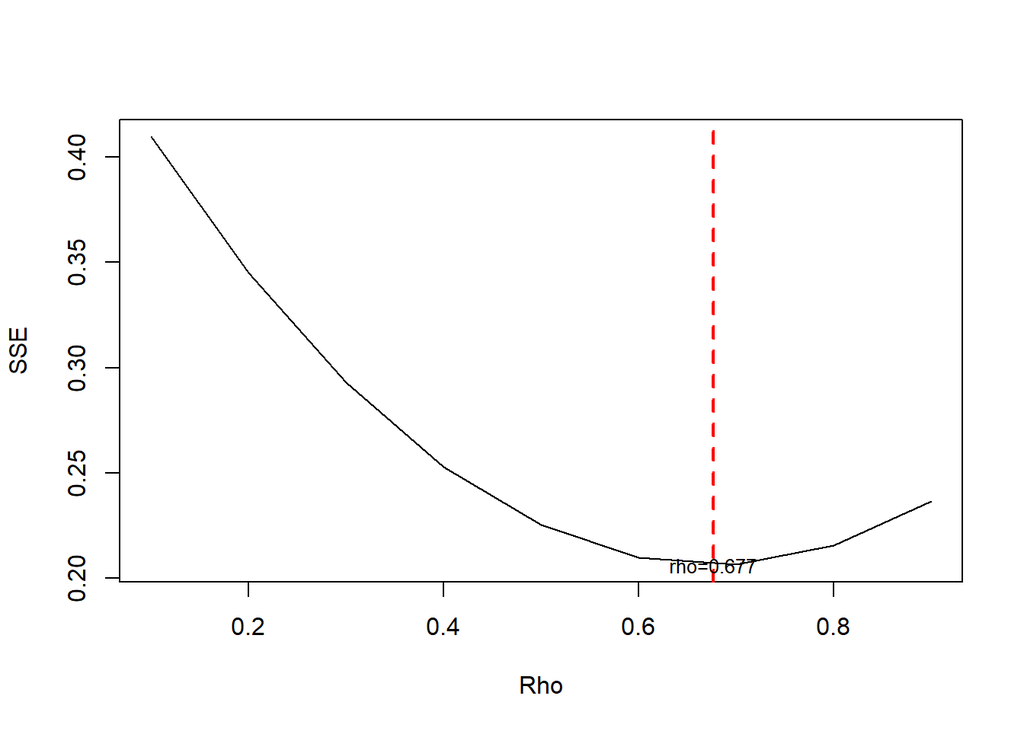

```r
#Grafik SSE optimum
par(mfrow = c(1,1))
plot(tab$SSE ~ tab$rho , type = "l", xlab = "Rho", ylab = "SSE")
abline(v = tabOpt[tabOpt$SSE==min(tabOpt$SSE),"rho"], lty = 2, col="red",lwd=2)
text(x=0.677, y=0.2059969, labels = "rho=0.677", cex = 0.8)
```

Berdasarkan hasil di atas, didapatkan nilai rho yang meminimumkan SSE adalah 0.677 dengan nilai SSE sebesar 0.2059969.

```r
#Model terbaik
modelHL <- hildreth.lu.func(0.677, model)
summary(modelHL)
```

```
##
## Call:
## lm(formula = y ~ x)
##
## Residuals:
##      Min       1Q   Median       3Q      Max
## -0.24385 -0.10196  0.04364  0.10120  0.12903
##
## Coefficients:
##               Estimate Std. Error t value Pr(>|t|)
## (Intercept) -304.65889   17.54342  -17.37 7.20e-10 ***
## x              0.50209    0.02689   18.67 3.11e-10 ***
## ---
## Signif. codes:  0 '***' 0.001 '**' 0.01 '*' 0.05 '.' 0.1 ' ' 1
##
## Residual standard error: 0.131 on 12 degrees of freedom
## Multiple R-squared:  0.9667, Adjusted R-squared:  0.9639
## F-statistic: 348.6 on 1 and 12 DF,  p-value: 3.111e-10
```

```r
#Transformasi Balik
cat("y = ", coef(modelHL)[1]/(1-0.677), "+", coef(modelHL)[2],"x", sep = "")
```

```
## y = -943.2164+0.5020927x
```

Setelah dilakukan penanganan autokorelasi dengan metode Hildreth-Lu, didapatkan model regresi baru yaitu
$$y_i=-943.2164+0.50209x_t$$

```r
#Deteksi autokorelasi
dwtest(modelHL)
```

```
##
##  Durbin-Watson test
##
## data:  modelHL
## DW = 1.5393, p-value = 0.1068
## alternative hypothesis: true autocorrelation is greater than 0
```

Berdasarkan uji Durbin-Watson didapatkan nilai *p-value* > $\alpha$ (5%). Artinya, belum cukup bukti untuk menyatakan ada autokorelasi pada model regresi ini.

# Perbandingan Model

```r
#Perbandingan
sseModelawal <- anova(model)$`Sum Sq`[-1]
sseModelCO <- anova(modelCOmanual)$`Sum Sq`[-1]
sseModelHL <- anova(modelHL)$`Sum Sq`[-1]
mseModelawal <- sseModelawal/length(IPM)
mseModelCO <- sseModelCO/length(IPM)
mseModelHL <- sseModelHL/length(IPM)
akurasi <- matrix(c(sseModelawal,sseModelCO,sseModelHL,
                    mseModelawal,mseModelCO,mseModelHL),nrow=2,ncol=3,byrow = T)
colnames(akurasi) <- c("Model Awal", "Model Cochrane-Orcutt", "Model Hildreth-Lu")
row.names(akurasi) <- c("SSE","MSE")
akurasi
```

```
##     Model Awal Model Cochrane-Orcutt Model Hildreth-Lu
## SSE 0.63127679            0.20599681        0.20599685
## MSE 0.04208512            0.01373312        0.01373312
```

Berdasarkan tabel di atas, dapat dilihat bahwa hasil penanganan autokorelasi dengan metode Cochrane-Orcutt lebih baik karena memiliki nilai SSE yang lebih kecil dibandingkan dengan metode Hildreth-Lu. Meski begitu, nilai MSE dari kedua metode tersebut memiliki nilai yang sama yaitu 0.01373312. Sehingga, dapat disimpulkan bahwa kedua metode tersebut sama baiknya dalam menangani autokorelasi pada model ini.